# Schwarz-Christoffel Conformal Mappings

Peter DeWitt

2016-09-11

The `sccm` package provides some tools for working with two-dimensional polygons, especially convex hulls, and mapping the data within these polygons/convex hulls to other polygons via Schwarz-Christoffel conformal mappings.

*Acknowledgements:* I would be remiss to not acknowledge two other R packages which greatly influenced the design of the `sccm` package.

- [`conformal`: https://r-forge.r-project.org/R/?group_id=973)](https://r-forge.r-project.org/R/?group_id=973) by Nick Ellis
- [`contoureR`: https://cran.r-project.org/web/packages/contoureR/index.html](https://cran.r-project.org/web/packages/contoureR/index.html) by Nicholas Hamilton.

The Schwarz-Christoffel conformal mappings are well described in

- Trefethen, Lloyd N. “Analysis and design of polygonal resistors by conformal mapping.” Zeitschrift für angewandte Mathematik und Physik ZAMP 35.5 (1984): 692-704.

Corresponding FORTRAN libraries are vailable from [SCPACK: http://www.netlib.org/conformal/](http://www.netlib.org/conformal/).

The particular set of functions provided by the `sccm` package are a minimum set of tools needed to map 2D data to a pre-defined support for regression models. The details and examples of the regression models are part of Peter DeWitt’s Ph.D. dissertation. More details on this can be found in the (soon to be released `cpr` package.

```r
set.seed(42)

# Required packages to re-create the following examples
library(sccm)
```

# Coordinate Translation

There are two functions provided to make it easy to move between Cartesian and polar coordinates:

1. `polar2cartesian(r, theta)` and
2. `cartesian2polar(x, y)`.

These function are based on the relationship
$$(x, y) = (r \cos(\theta), r \sin(\theta)).$$

Both functions expect that the inputs are numeric vectors of equal length or, if one input is length 1, it will be repeated to match the length of the other input. Examples below

```r
# return the Cartesian coordinates of the point on the unit circle with and
# angle of 2 pi/ 3
cart <- polar2cartesian(r = 1, theta = 2 * pi / 3)
cart
```

```
##      [,1]      [,2]
## [1,] -0.5 0.8660254
```

```r
all.equal(cart, matrix(c(-0.5, sqrt(3) / 2), nrow = 1)
)
```

```
## [1] TRUE
```

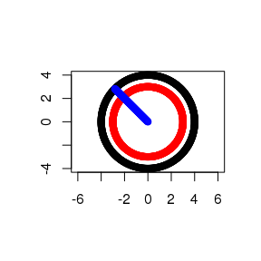

```r
# Return a disk of a given radius, or a radii of a
disk3 <- polar2cartesian(r = 3, theta = seq(0, 2 * pi, length = 500L))
disk4 <- polar2cartesian(r = 4, theta = seq(0, 2 * pi, length = 500L))
radii <- polar2cartesian(r = seq(0, 4, length = 100L), theta = 0.75 * pi)

plot(disk4, col = "black", asp = 1, xlab = "", ylab = "")
points(disk3, col = "red")
points(radii, col = "blue")
```

`cartesian2polar` translates an $(x, y)$ Cartesian coordinates to $(r, \theta)$ polar coordinates.

```r
cartesian2polar(-0.5, sqrt(3)/2)
```

```
##      [,1]     [,2]
## [1,]    1 2.094395
```

```r
all.equal(cartesian2polar(-0.5, sqrt(3)/2),
          matrix(c(1, 2 * pi / 3), nrow = 1))
```

```
## [1] TRUE
```

# Polygons and Convex Hulls

The conformal mappings will require the use of polygons. The functions `sccm::polygon` and `sccm::convex_hull` are provided to make defining the polygons easy. The function `is_in` determines if a given point is either inside, on an edge, or outside of a given polygon.

## `polygon`

The expected input for `polygon` are two numeric vectors, or a `matrix`, or a `data.frame`. Any R object that can be coerced into a two column `matrix` could be passed to `sccm::polygon`.

For the set of vertices $\left\{ (1, -1), (1, 0), (2, 2), (3, -2) \right\}$ the polygon is defined via:

```r
pg <- polygon(x = c( 1, 1, 2,  3),
              y = c(-1, 0, 2, -2))

pg
## A polygon with 4 vertices.
##      x  y
## [1,] 1 -1
## [2,] 1  0
## [3,] 2  2
## [4,] 3 -2

class(pg)
```

```
## [1] "sccm_pg" "list"
```

```r
str(pg)
```

```
## List of 2
##  $ vertices: num [1:4, 1:2] 1 1 2 3 -1 0 2 -2
##   ..- attr(*, "dimnames")=List of 2
##   .. ..$ : NULL
##   .. ..$ : chr [1:2] "x" "y"
##  $ beta    : num [1:4] -1.107 -0.464 -2.433 -2.279
##  - attr(*, "class")= chr [1:2] "sccm_pg" "list"
```

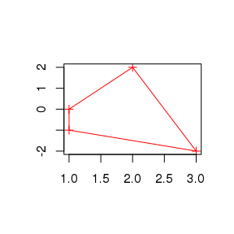

```r
plot(pg)
```

$$\beta_{j} = \text{atan2} \left( \overrightarrow{v_{j-1}v_{j}} \times \overrightarrow{v_{j}v_{j+1}}, \overrightarrow{v_{j-1}v_{j}} \cdot \overrightarrow{v_{j}v_{j+1}}\right)$$

The cross product of the vectors by the dot product provides the needed inputs for determining the exterior angle of each vertex.

It is important to note that `sccm::polygon` returns the vertices of the polygon in the same order as they inputted. For the conformal mappings we will need the vertices to be entered in anti-clockwise order. The user is expected to determine the correct sequence when constructing a polygon.

To illustrate the ordering of the vertices we will construct a five pointed star polygon.

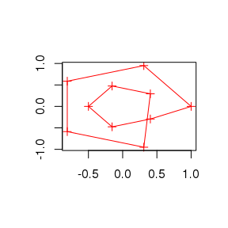

```r
star <-
  rbind(polar2cartesian(1.0, seq(0, 1.6, by = 0.4) * pi),
        polar2cartesian(0.5, seq(0.2, 1.8, by = 0.4) * pi))

plot(polygon(star))
```

Notice that the vertices on the unit disk are listed before the vertices on a disk of radius 0.5 and the plot reflex this. While the plot is a polygon, albeit an irregular polygon, it does not look like a star, a regular concave polygon. Next we will put the vertices in the correct order and generate a new plot. This `star_pg` polygon will be used in several examples to follow.

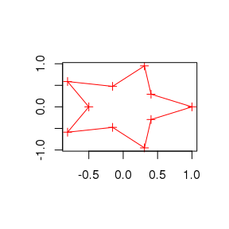

```r
star <- star[rep(1:5, each = 2) + rep(c(0, 5), times = 5), ]
star_pg <- polygon(star)
plot(star_pg)
```

## `convex_hull`

A convex hull is the smallest convex envelop containing all the points of a set. The construction of these convex hulls is done via Andrew’s Monotone Theorem, a $O(n log n)$ order algorithm. A brute force approach for finding convex hulls can be $O(n^3).$

The function `convex_hull` will accept a $n \times 2$ `matrix` or `data.frame` or two numeric vectors given the $(x, y)$ coordinates of the data. The function will then return the vertices of the convex hull along with the exterior angles at each vertices and the row index of the original data for each of the vertices. It is also worth noting that the origin data is returned within the `list` structure of `sccm_ch` objects.

```r
xvec = runif(150)
yvec = 2 * xvec + rnorm(150)

ch <- convex_hull(xvec, yvec)

ch
## A convex hull with 12 vertices.
##                  x          y
##  [1,] 0.0002388966 -0.9922147
##  [2,] 0.0078847387 -1.5357753
##  [3,] 0.3984854114 -1.2277070
##  [4,] 0.9575765966  0.4215281
##  [5,] 0.9888917289  0.5185695
##  [6,] 0.9828171979  1.8483148
##  [7,] 0.9625702936  3.0964657
##  [8,] 0.9400145228  3.2721454
##  [9,] 0.8214039239  3.6797800
## [10,] 0.0374310329  2.7767531
## [11,] 0.0039483388  0.1270576
## [12,] 0.0013808436 -0.3423263

class(ch)
```

```
## [1] "sccm_ch" "sccm_pg" "list"
```

```r
str(ch)
```

```
## List of 4
##  $ vertices: num [1:12, 1:2] 0.000239 0.007885 0.398485 0.957577 0.988892 ...
##   ..- attr(*, "dimnames")=List of 2
##   .. ..$ : NULL
##   .. ..$ : chr [1:2] "x" "y"
##  $ data    : num [1:150, 1:2] 0.915 0.937 0.286 0.83 0.642 ...
##  $ beta    : num [1:12] 0.0158 2.2245 0.5761 0.0147 0.3167 ...
##  $ indices : num [1:12] 92 77 53 46 23 62 128 16 137 43 ...
##  - attr(*, "class")= chr [1:3] "sccm_ch" "sccm_pg" "list"
```

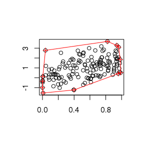

```r
plot(ch)
```

Using the `mtcars` data set, we can build a convex hull about the weight of vertices and the miles per gallon.

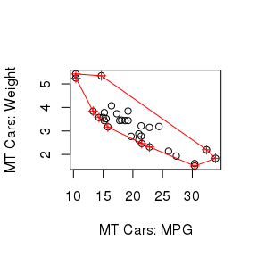

```r
plot(convex_hull(mtcars[, c("mpg", "wt")]))
title(xlab = "MT Cars: MPG", ylab = "MT Cars: Weight")
```